# 그래프를 그리는 plotting 도구: matplotlib, seaborn

# seaborn의 내장 데이터 셋으로 데이터 분포 살펴보기

### 컬럼 설명

total_bill: 총 합계 요금표  
tip: 팁  
sex: 성별  
smoker: 흡연자 여부  
day: 요일  
time: 식사 시간  
size: 식사 인원

```python
# seaborn 임포트,  한글 글꼴 지정
import seaborn as sns
sns.set()
plt.rc('font', family='NanumBarunGothic')
```

```python
 # 내장 데이터 셋 불러오기
 tips = sns.load_dataset('tips')
```

```python
tips.describe()
```

|  | total_bill | tip | size |
| --- | --- | --- | --- |
| count | 244.000000 | 244.000000 | 244.000000 |
| mean | 19.785943 | 2.998279 | 2.569672 |
| std | 8.902412 | 1.383638 | 0.951100 |
| min | 3.070000 | 1.000000 | 1.000000 |
| 25% | 13.347500 | 2.000000 | 2.000000 |
| 50% | 17.795000 | 2.900000 | 2.000000 |
| 75% | 24.127500 | 3.562500 | 3.000000 |
| max | 50.810000 | 10.000000 | 6.000000 |

```python
tips.head()    # dataframe의 앞부분만 살펴보기
```

|  | total_bill | tip | sex | smoker | day | time | size |
| --- | --- | --- | --- | --- | --- | --- | --- |
| 0 | 16.99 | 1.01 | Female | No | Sun | Dinner | 2 |
| 1 | 10.34 | 1.66 | Male | No | Sun | Dinner | 3 |
| 2 | 21.01 | 3.50 | Male | No | Sun | Dinner | 3 |
| 3 | 23.68 | 3.31 | Male | No | Sun | Dinner | 2 |
| 4 | 24.59 | 3.61 | Female | No | Sun | Dinner | 4 |

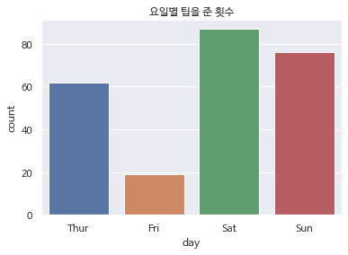

```python
# 막대그래프
sns.countplot(data=tips, x= 'day')
plt.title("요일별 팁을 준 횟수")
```

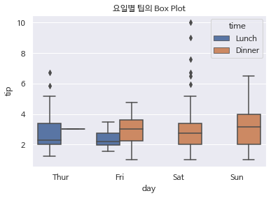

```python
# boxplot
sns.boxplot(data=tips, x='day', y='tip', hue='time')
plt.title("요일별 팁의 Box Plot")
```

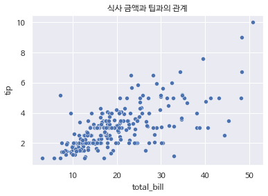

```python
#scatterplot()
sns.scatterplot(data=tips,x='total_bill',y='tip')
plt.title('식사 금액과 팁과의 관계')
```

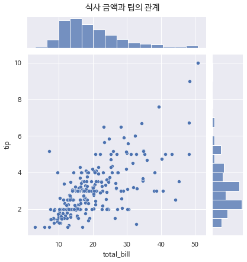

```python
# scatter과 bar를 합치고 싶을 때에는 seaborn 의 jointplot 사용
# 우선 data로 데이터를 주고, x축 y축에 표기할 데이터를 각각 쓴다.
sns.jointplot(data=tips, x='total_bill', y='tip')
plt.suptitle('식사 금액과 팁의 관계', y=1.02)
```

[figure not shown]

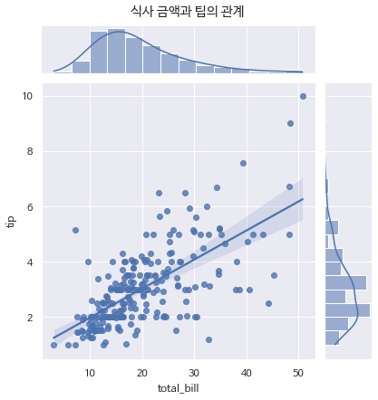

```python
sns.jointplot(data=tips, x='total_bill', y='tip', kind='reg')
plt.suptitle('식사 금액과 팁의 관계', y=1.02)
```

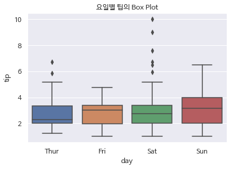

```python
sns.boxplot(data=tips, x='day', y='tip')
plt.title("요일별 팁의 Box Plot")
```

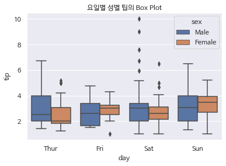

```python
#요일별, 성별 팀의 4분위 범위 확인 및 이상치(outlier) 확인
sns.boxplot(data=tips, x='day', y='tip', hue='sex')
plt.title("요일별 성별 팁의 Box Plot")
```

[figure not shown]

```python
#violin plot
```

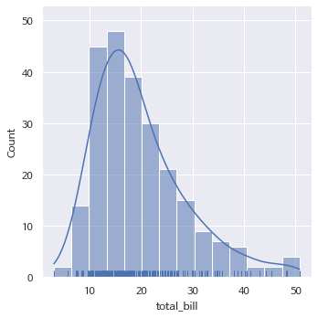

```python
#sns.distplot() -> sns.displot()으로 버전업
sns.displot(data=tips,x='total_bill',kde=True,rug=True)
```

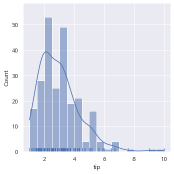

```python
#kde 옵션: 밀집도 그래프, rug 옵션: 데이터의 위치를 나타내는 선분 표시
sns.displot(data=tips,x='tip',kde=True,rug=True)
```

[figure not shown]

```python
#kde 옵션: 밀집도 그래프, rug 옵션: 데이터의 위치를 나타내는 선분 표시, bin : 분포 구분 갯수
```

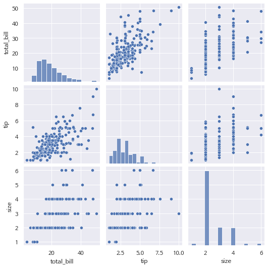

```python
#pairplot은 각각 쌍의 그래프를 보여준다.
sns.pairplot(tip)
```

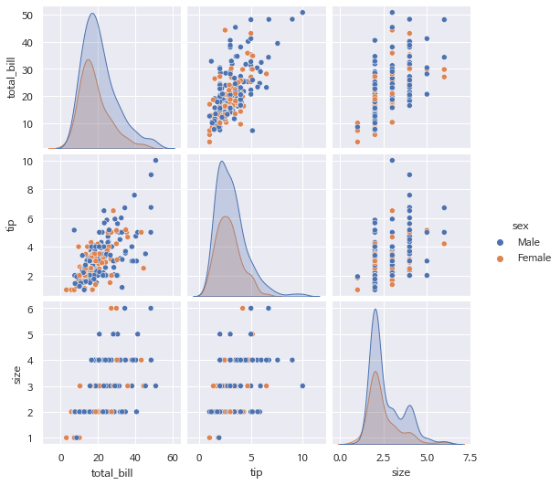

```python
#pairplot은 각각 쌍의 그래프를 보여준다.
# hue = 'sex'의 상관관계도 볼 수 있음.
sns.pairplot(tip,hue='sex')
```

### <연습문제 2>

성별 별로, 팁을 준 횟수를 차트로 그려보세요

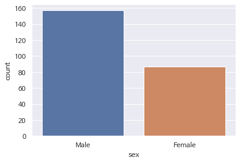

```python
sns.countplot(data=tips,x='sex')
```

### <연습문제 3>

각 컬럼관의 상관관계를 보고, 시간에 따른 분포도 볼 수 있는 그래프를 그려보세요.

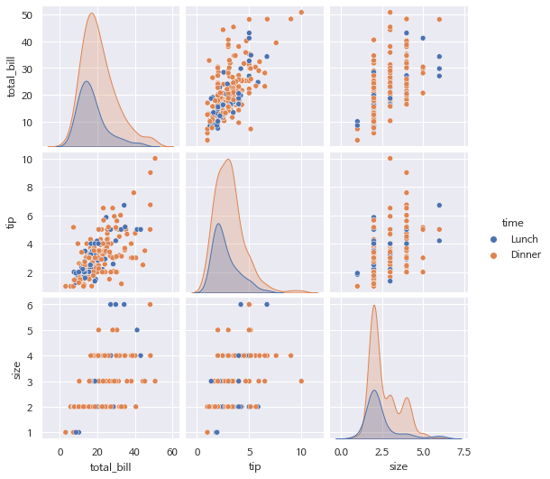

```python
sns.pairplot(tip,hue='time')
```

### <연습문제4>

4분위 분포와 outlier(이상치)를 보려고 합니다. 인원별, 시간대별, 팁의 현황을 확인하는 그래프 그려보세요.

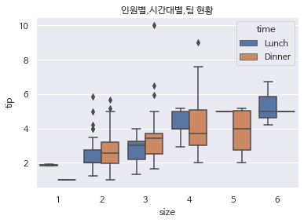

```python
sns.boxplot(data=tips,x='size',y='tip',hue='time')
plt.title('인원별,시간대별,팀 현황')
```

```python
tips.head()
```

|  | total_bill | tip | sex | smoker | day | time | size |
| --- | --- | --- | --- | --- | --- | --- | --- |
| 0 | 16.99 | 1.01 | Female | No | Sun | Dinner | 2 |
| 1 | 10.34 | 1.66 | Male | No | Sun | Dinner | 3 |
| 2 | 21.01 | 3.50 | Male | No | Sun | Dinner | 3 |
| 3 | 23.68 | 3.31 | Male | No | Sun | Dinner | 2 |
| 4 | 24.59 | 3.61 | Female | No | Sun | Dinner | 4 |

### <연습문제5>

컬럼별로 sns.heatmap()으로 상관관계를 보려고 합니다. 어떻게 해야하는지 문제를 해결를 해 보세요. 명령은 다음과 같습니다.

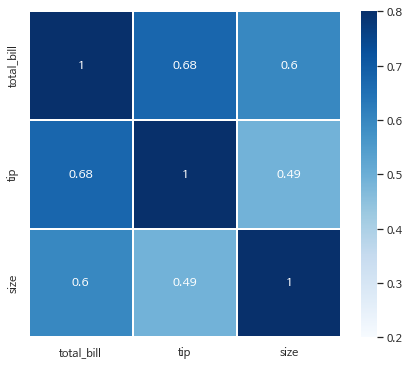

```python
# heatmap() 각 컬럼별로 상관계를 보기 위한 그래프
corr = tips.corr() # 컬럼간 상관관계를 만들어 주는 함수
plt.figure(figsize=(7,6))
sns.heatmap(corr, # 데이터
            vmin=0.2, # 최솟값
            vmax=0.8, # 최댓값
            linewidths=0.01, # 라인값
            cbar=True, # 관계성 지수바 (corr bar) 표시
            square=False,
            center=0.5,
            annot=True, # 셀의 관계성 숫자로 표현
            cmap="Blues") # color map
```

### <연습문제 6>

tips 테이블의 범주형 컬럼의 데이터를 숫자로 바꿔보세요.

```python
tips.head()
```

|  | total_bill | tip | sex | smoker | day | time | size |
| --- | --- | --- | --- | --- | --- | --- | --- |
| 0 | 16.99 | 1.01 | Female | No | Sun | Dinner | 2 |
| 1 | 10.34 | 1.66 | Male | No | Sun | Dinner | 3 |
| 2 | 21.01 | 3.50 | Male | No | Sun | Dinner | 3 |
| 3 | 23.68 | 3.31 | Male | No | Sun | Dinner | 2 |
| 4 | 24.59 | 3.61 | Female | No | Sun | Dinner | 4 |

#### 적절한 함수 이용해서 해결하기

```python
#'sex', 'smoker', 'day', 'time'
tips['time'].value_counts()
```

```
Dinner    176
Lunch      68
Name: time, dtype: int64
```

```python
tips
```

|  | total_bill | tip | sex | smoker | day | time | size |
| --- | --- | --- | --- | --- | --- | --- | --- |
| 0 | 16.99 | 1.01 | Female | No | Sun | Dinner | 2 |
| 1 | 10.34 | 1.66 | Male | No | Sun | Dinner | 3 |
| 2 | 21.01 | 3.50 | Male | No | Sun | Dinner | 3 |
| 3 | 23.68 | 3.31 | Male | No | Sun | Dinner | 2 |
| 4 | 24.59 | 3.61 | Female | No | Sun | Dinner | 4 |
| ... | ... | ... | ... | ... | ... | ... | ... |
| 239 | 29.03 | 5.92 | Male | No | Sat | Dinner | 3 |
| 240 | 27.18 | 2.00 | Female | Yes | Sat | Dinner | 2 |
| 241 | 22.67 | 2.00 | Male | Yes | Sat | Dinner | 2 |
| 242 | 17.82 | 1.75 | Male | No | Sat | Dinner | 2 |
| 243 | 18.78 | 3.00 | Female | No | Thur | Dinner | 2 |

244 rows × 7 columns

```python
from IPython.core.display import display, HTML
display(HTML("<style>.container {width:90% !important;}</style>"))
```